# R Notebook Projet 6

# ETUDE DE L’EVOLUTION DU CHIFFRE D’AFFAIRES ET DES RELATIONS PRODUITS ET CLIENTS / LIBRAIRIE LAPAGE

[figure not shown]

Logo Lapage

```r
library(tidyverse)
```

## PREPARATION ET EXPLORATION DES DONNEES

```r
customers  <-  read_csv("customers.csv", col_names = TRUE)
head(customers)
```

| client_id | sex | birth |
| --- | --- | --- |
| c_4410 | f | 1967 |
| c_7839 | f | 1975 |
| c_1699 | f | 1984 |
| c_5961 | f | 1962 |
| c_5320 | m | 1943 |
| c_415 | m | 1993 |

```r
summary(customers)
```

```
  client_id             sex                birth
 Length:8623        Length:8623        Min.   :1929
 Class :character   Class :character   1st Qu.:1966
 Mode  :character   Mode  :character   Median :1979
                                       Mean   :1978
                                       3rd Qu.:1992
                                       Max.   :2004
```

```r
sum(duplicated(customers)) # pas de doublon
```

```
[1] 0
```

```r
products <- read_csv("products.csv", col_names = TRUE)
head(products)
```

| id_prod | price | categ |
| --- | --- | --- |
| 0_1421 | 19.99 | 0 |
| 0_1368 | 5.13 | 0 |
| 0_731 | 17.99 | 0 |
| 1_587 | 4.99 | 1 |
| 0_1507 | 3.99 | 0 |
| 0_1163 | 9.99 | 0 |

```r
summary(products)
```

```
   id_prod              price            categ
 Length:3287        Min.   : -1.00   Min.   :0.0000
 Class :character   1st Qu.:  6.99   1st Qu.:0.0000
 Mode  :character   Median : 13.06   Median :0.0000
                    Mean   : 21.86   Mean   :0.3702
                    3rd Qu.: 22.99   3rd Qu.:1.0000
                    Max.   :300.00   Max.   :2.0000
```

Des produits ont un prix négatif. Examen.

```r
products %>%
  filter(price == -1)
```

| id_prod | price | categ |
| --- | --- | --- |
| T_0 | -1 | 0 |

Un seul produit concerné, T_0. Avoir ou autre ? A noter.

```r
sum(duplicated(products)) # pas de doublon
```

```
[1] 0
```

```r
transactions <- read_csv("transactions.csv", col_names = TRUE)
head(transactions)
```

| id_prod | date | session_id | client_id |
| --- | --- | --- | --- |
| 0_1518 | 2022-05-20 13:21:29 | s_211425 | c_103 |
| 1_251 | 2022-02-02 07:55:19 | s_158752 | c_8534 |
| 0_1277 | 2022-06-18 15:44:33 | s_225667 | c_6714 |
| 2_209 | 2021-06-24 04:19:29 | s_52962 | c_6941 |
| 0_1509 | 2023-01-11 08:22:08 | s_325227 | c_4232 |
| 0_1418 | 2022-10-20 15:59:16 | s_285425 | c_1478 |

```r
summary(transactions)
```

```
   id_prod               date                         session_id         client_id
 Length:679532      Min.   :2021-03-01 00:01:07.83   Length:679532      Length:679532
 Class :character   1st Qu.:2021-09-08 09:14:25.05   Class :character   Class :character
 Mode  :character   Median :2022-03-03 07:50:20.81   Mode  :character   Mode  :character
                    Mean   :2022-03-03 15:13:19.30
                    3rd Qu.:2022-08-30 23:57:08.55
                    Max.   :2023-02-28 23:58:30.78
                    NA's   :200
```

*Il manque 200 dates dans les données.*

```r
problems(transactions) # retourne les valeurs posant problèmes de traitement / package {vroom}
```

| row | col | expected | actual | file |
| --- | --- | --- | --- | --- |
| 3021 | 2 | date in ISO8601 | test_2021-03-01 02:30:02.237419 | D:/Docs_T/Data_Analyst/Formation/Projets_DA/Projet_06/transactions.csv |
| 5140 | 2 | date in ISO8601 | test_2021-03-01 02:30:02.237425 | D:/Docs_T/Data_Analyst/Formation/Projets_DA/Projet_06/transactions.csv |
| 9670 | 2 | date in ISO8601 | test_2021-03-01 02:30:02.237437 | D:/Docs_T/Data_Analyst/Formation/Projets_DA/Projet_06/transactions.csv |
| 10730 | 2 | date in ISO8601 | test_2021-03-01 02:30:02.237436 | D:/Docs_T/Data_Analyst/Formation/Projets_DA/Projet_06/transactions.csv |
| 15294 | 2 | date in ISO8601 | test_2021-03-01 02:30:02.237430 | D:/Docs_T/Data_Analyst/Formation/Projets_DA/Projet_06/transactions.csv |
| 19314 | 2 | date in ISO8601 | test_2021-03-01 02:30:02.237449 | D:/Docs_T/Data_Analyst/Formation/Projets_DA/Projet_06/transactions.csv |
| 23680 | 2 | date in ISO8601 | test_2021-03-01 02:30:02.237430 | D:/Docs_T/Data_Analyst/Formation/Projets_DA/Projet_06/transactions.csv |
| 23698 | 2 | date in ISO8601 | test_2021-03-01 02:30:02.237444 | D:/Docs_T/Data_Analyst/Formation/Projets_DA/Projet_06/transactions.csv |
| 27780 | 2 | date in ISO8601 | test_2021-03-01 02:30:02.237437 | D:/Docs_T/Data_Analyst/Formation/Projets_DA/Projet_06/transactions.csv |
| 35435 | 2 | date in ISO8601 | test_2021-03-01 02:30:02.237418 | D:/Docs_T/Data_Analyst/Formation/Projets_DA/Projet_06/transactions.csv |

[output cut: 190 more lines]

```r
filter(transactions, is.na(transactions$date))
```

| id_prod | date | session_id | client_id |
| --- | --- | --- | --- |
| T_0 |  | s_0 | ct_0 |
| T_0 |  | s_0 | ct_0 |
| T_0 |  | s_0 | ct_1 |
| T_0 |  | s_0 | ct_0 |
| T_0 |  | s_0 | ct_0 |
| T_0 |  | s_0 | ct_0 |
| T_0 |  | s_0 | ct_1 |
| T_0 |  | s_0 | ct_0 |
| T_0 |  | s_0 | ct_1 |
| T_0 |  | s_0 | ct_1 |

[output cut: 190 more lines]

```r
filter(transactions, transactions$id_prod == "T_0")
```

| id_prod | date | session_id | client_id |
| --- | --- | --- | --- |
| T_0 |  | s_0 | ct_0 |
| T_0 |  | s_0 | ct_0 |
| T_0 |  | s_0 | ct_1 |
| T_0 |  | s_0 | ct_0 |
| T_0 |  | s_0 | ct_0 |
| T_0 |  | s_0 | ct_0 |
| T_0 |  | s_0 | ct_1 |
| T_0 |  | s_0 | ct_0 |
| T_0 |  | s_0 | ct_1 |
| T_0 |  | s_0 | ct_1 |

[output cut: 190 more lines]

*Visiblement, il s’agit d’un test ayant eu lieu à la même date et portant la mention “test_2021-03-01”. Les lignes sont à supprimer.*

```r
transactions <- transactions %>%
  filter(transactions$id_prod != "T_0")
summary(transactions)  # 679532 - 679332 = 200 , le compte est bon
```

```
   id_prod               date                         session_id         client_id
 Length:679332      Min.   :2021-03-01 00:01:07.83   Length:679332      Length:679332
 Class :character   1st Qu.:2021-09-08 09:14:25.05   Class :character   Class :character
 Mode  :character   Median :2022-03-03 07:50:20.81   Mode  :character   Mode  :character
                    Mean   :2022-03-03 15:13:19.30
                    3rd Qu.:2022-08-30 23:57:08.55
                    Max.   :2023-02-28 23:58:30.78
```

```r
sum(duplicated(transactions)) # pas de doublon
```

```
[1] 0
```

En toute rigueur, il convient également de corriger le dataframe *products* qui contient le produit T_0.

```r
products <- products %>%
  filter(id_prod != "T_0")
```

```r
library(questionr)
freq(table(products$categ))  # nombre de produits par catégorie et pourcentages associés
```

|  | n | % | val% |
| --- | --- | --- | --- |
| 0 | 2308 | 70.2 | 70.2 |
| 1 | 739 | 22.5 | 22.5 |
| 2 | 239 | 7.3 | 7.3 |

**Fusion des données transactions et products**

```r
trans_prod <- transactions %>%
  tidylog::left_join(products, by = "id_prod")   # {tidylog} rend la fonction dplyr plus bavard
```

```
left_join: added 2 columns (price, categ)
           > rows only in x       221
           > rows only in y  (     21)
           > matched rows     679,111
           >                 =========
           > rows total       679,332
```

```r
head(trans_prod)
```

| id_prod | date | session_id | client_id | price | categ |
| --- | --- | --- | --- | --- | --- |
| 0_1518 | 2022-05-20 13:21:29 | s_211425 | c_103 | 4.18 | 0 |
| 1_251 | 2022-02-02 07:55:19 | s_158752 | c_8534 | 15.99 | 1 |
| 0_1277 | 2022-06-18 15:44:33 | s_225667 | c_6714 | 7.99 | 0 |
| 2_209 | 2021-06-24 04:19:29 | s_52962 | c_6941 | 69.99 | 2 |
| 0_1509 | 2023-01-11 08:22:08 | s_325227 | c_4232 | 4.99 | 0 |
| 0_1418 | 2022-10-20 15:59:16 | s_285425 | c_1478 | 8.57 | 0 |

```r
summary(trans_prod)
```

```
   id_prod               date                         session_id         client_id             price            categ
 Length:679332      Min.   :2021-03-01 00:01:07.83   Length:679332      Length:679332      Min.   :  0.62   Min.   :0.000
 Class :character   1st Qu.:2021-09-08 09:14:25.05   Class :character   Class :character   1st Qu.:  8.87   1st Qu.:0.000
 Mode  :character   Median :2022-03-03 07:50:20.81   Mode  :character   Mode  :character   Median : 13.99   Median :0.000
                    Mean   :2022-03-03 15:13:19.30                                         Mean   : 17.45   Mean   :0.442
                    3rd Qu.:2022-08-30 23:57:08.55                                         3rd Qu.: 18.99   3rd Qu.:1.000
                    Max.   :2023-02-28 23:58:30.78                                         Max.   :300.00   Max.   :2.000
                                                                                           NA's   :221      NA's   :221
```

*Il manque 221 prix et 221 entrées catégories.*

```r
trans_prod[is.na(trans_prod$categ) | is.na(trans_prod$price),] %>%
  group_by(id_prod) %>%
  count()
```

| id_prod | n |
| --- | --- |
| 0_2245 | 221 |

Un seul produit est concerné : le 0_2245, à 221 reprises. Son préfixe le désignerait comme faisant partie de la catégorie 0. Attribution, à défaut, de la valeur médiane des prix des produits de catégorie 0.

```r
med_price_cat_0 <-
  median(trans_prod[trans_prod$categ == 0,]$price, na.rm = TRUE)
trans_prod[is.na(trans_prod$categ), ]$categ <- 0
trans_prod[is.na(trans_prod$price), ]$price <- med_price_cat_0
```

```r
table(trans_prod[trans_prod$id_prod == "0_2245", ]$price, trans_prod[trans_prod$id_prod ==
                                                                       "0_2245", ]$categ)
```

```
         0
  9.99 221
```

## ANALYSE DES DONNEES

### Analyse de la répartition du chiffre d’affaires

*Chiffre d’affaires = somme des prix des produits vendus lors des transactions*

```r
CA_total <- sum(trans_prod$price)
CA_total
```

```
[1] 11855936
```

**CA par produit**

```r
CA_prod <- trans_prod %>%
  group_by(id_prod) %>%
  summarise(CA = sum(price, na.rm = TRUE))
head(CA_prod)
```

| id_prod | CA |
| --- | --- |
| 0_0 | 4657.50 |
| 0_1 | 5352.13 |
| 0_10 | 394.90 |
| 0_100 | 61.80 |
| 0_1000 | 2954.88 |
| 0_1001 | 2020.95 |

```r
summary(CA_prod)
```

```
   id_prod                CA
 Length:3266        Min.   :    0.99
 Class :character   1st Qu.:  233.83
 Mode  :character   Median :  797.22
                    Mean   : 3630.11
                    3rd Qu.: 3406.20
                    Max.   :94893.50
```

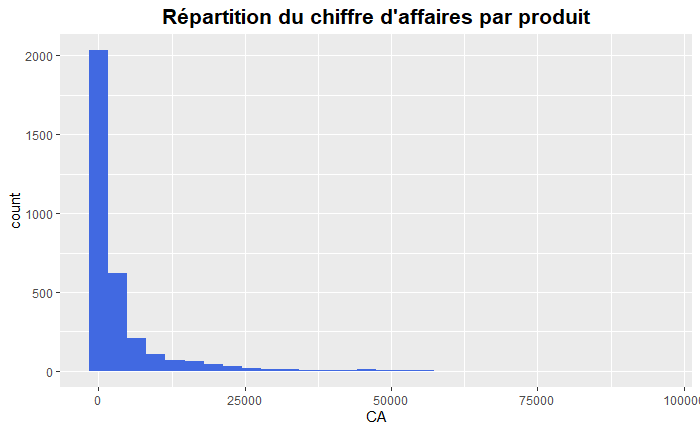

```r
ggplot(CA_prod) +
  aes(x = CA) +
  geom_histogram(bins = 30L, fill = "royalblue") +
  labs(title = "Répartition du chiffre d'affaires par produit") +
  theme_grey() +
  theme(plot.title = element_text(size = 16L,
                                  face = "bold",
                                  hjust = 0.5))
```

**Relevé de quelques données significatives concernant le CA des produits.**

```r
# Les 6 premiers produits classés par CA
head(CA_prod %>%
       arrange(desc(CA)))
```

| id_prod | CA |
| --- | --- |
| 2_159 | 94893.50 |
| 2_135 | 69334.95 |
| 2_112 | 65407.76 |
| 2_102 | 60736.78 |
| 2_209 | 56971.86 |
| 1_395 | 54356.25 |

```r
# Les 6 derniers produits pour le CA / summary() a déjà donné moyenne, médiane et valeurs extrêmes.
head(CA_prod %>%
       arrange(CA))
```

| id_prod | CA |
| --- | --- |
| 0_1539 | 0.99 |
| 0_1284 | 1.38 |
| 0_1653 | 1.98 |
| 0_1601 | 1.99 |
| 0_541 | 1.99 |
| 0_807 | 1.99 |

#### Mesure de l’inégalité des produits en matière de CA.

```r
library(ineq) # package {ineq} Inequality Measures
```

**Courbe de Lorenz de la répartition du CA par produit**

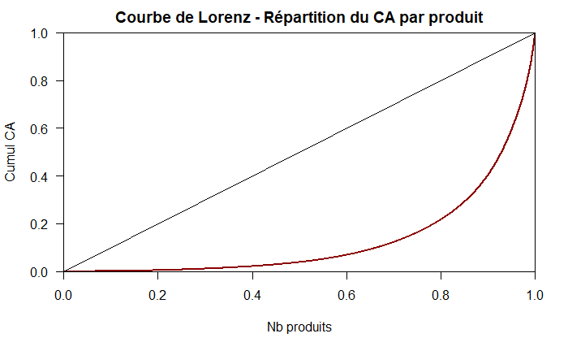

```r
plot(Lc(CA_prod$CA), col = "darkred", lwd = 2, main="Courbe de Lorenz - Répartition du CA par produit", xlab = "Nb produits", ylab= "Cumul CA")
```

On compare les valeurs cumulées des déciles avec la droite d’équi-répartition, c’est une estimation de l’inégalité. Ici très marquée.

**Indice ou coefficient de Gini**

```r
ineq(CA_prod$CA, type = "Gini") # G = 2*AUC / plus G est fort, plus l'inégalité est forte. O = égalité parfaite, 1 inégalité parfaite jamais atteinte.
```

```
[1] 0.7428386
```

**CA par catégories**

```r
CA_categ  <- trans_prod %>%
  group_by(categ) %>%
  summarise(CA = sum(price),
            prop = round(sum(price) / CA_total * 100, 2))
CA_categ
```

| categ | CA | prop |
| --- | --- | --- |
| 0 | 4421939 | 37.30 |
| 1 | 4653723 | 39.25 |
| 2 | 2780275 | 23.45 |

### Analyse de tendance et saisonnalité

#### Préparation des données temporelles

**Regroupement des dates par mois**

```r
trans_prod$periode <- format(trans_prod$date, "%y-%m")
trans_prod$date_courte <- as.Date(trans_prod$date)
```

```r
summary(trans_prod)
```

```
   id_prod               date                         session_id         client_id             price            categ
 Length:679332      Min.   :2021-03-01 00:01:07.83   Length:679332      Length:679332      Min.   :  0.62   Min.   :0.0000
 Class :character   1st Qu.:2021-09-08 09:14:25.05   Class :character   Class :character   1st Qu.:  8.87   1st Qu.:0.0000
 Mode  :character   Median :2022-03-03 07:50:20.81   Mode  :character   Mode  :character   Median : 13.99   Median :0.0000
                    Mean   :2022-03-03 15:13:19.30                                         Mean   : 17.45   Mean   :0.4418
                    3rd Qu.:2022-08-30 23:57:08.55                                         3rd Qu.: 18.99   3rd Qu.:1.0000
                    Max.   :2023-02-28 23:58:30.78                                         Max.   :300.00   Max.   :2.0000
   periode           date_courte
 Length:679332      Min.   :2021-03-01
 Class :character   1st Qu.:2021-09-08
 Mode  :character   Median :2022-03-03
                    Mean   :2022-03-03
                    3rd Qu.:2022-08-30
                    Max.   :2023-02-28
```

```r
## Transtypage custom_prod$categ en factor
trans_prod$categ <- trans_prod$categ %>%
  as.character() %>%
  as.factor()
```

```r
CA_periode  <-  trans_prod %>%
  group_by(periode) %>%
  summarise(CA = sum(price),
            prop = round(sum(price) / CA_total * 100, 2),
            count = n())
CA_periode
```

| periode | CA | prop | count |
| --- | --- | --- | --- |
| 21-03 | 482530.5 | 4.07 | 28610 |
| 21-04 | 476249.2 | 4.02 | 28457 |
| 21-05 | 493023.4 | 4.16 | 28293 |
| 21-06 | 484158.5 | 4.08 | 26857 |
| 21-07 | 482875.4 | 4.07 | 24742 |
| 21-08 | 482374.7 | 4.07 | 25659 |
| 21-09 | 507360.6 | 4.28 | 33326 |
| 21-10 | 320868.7 | 2.71 | 21606 |
| 21-11 | 516267.6 | 4.35 | 28321 |
| 21-12 | 525987.2 | 4.44 | 32464 |

[output cut: 14 more lines]

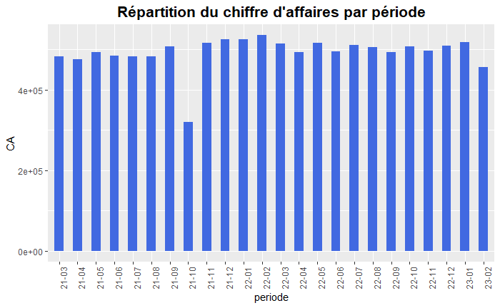

```r
CA_periode %>%
  ggplot(aes(x = periode, y = CA)) +
  geom_col(width = 0.5, fill = "royalblue") +
  labs(title = "Répartition du chiffre d'affaires par période") +
  theme_grey() +
  theme(plot.title = element_text(size = 16L,
                                  face = "bold",
                                  hjust = 0.5)) +
  theme(axis.text.x = element_text(angle = 90))
```

**Que s’est-il passé en octobre 2021 ?**

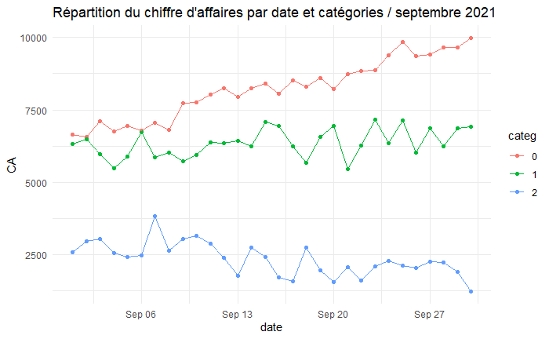

```r
trans_prod[trans_prod$periode == "21-09",] %>%
  group_by(categ, date_courte) %>%
  summarise(CA = sum(price)) %>%
  ggplot(aes(x = date_courte, y = CA, colour = categ)) +
  geom_point() +
  geom_line() +
  scale_color_hue(direction = 1) +
  labs(title = "Répartition du chiffre d'affaires par date et catégories / septembre 2021") +
  labs(x = "date") +
  theme(plot.title = element_text(size = 16L,
                                  face = "bold",
                                  hjust = 0.5)) +
  theme(axis.text.x = element_text(angle = 90)) +
  theme_minimal()
```

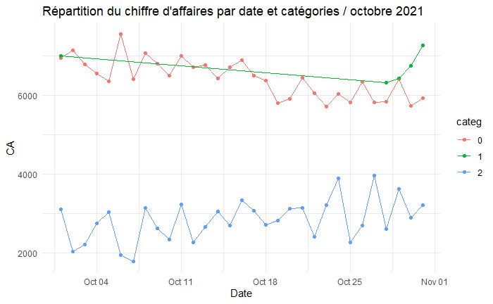

```r
trans_prod[trans_prod$periode == "21-10",] %>%
  group_by(categ, date_courte) %>%
  summarise(CA = sum(price)) %>%
  ggplot(aes(x = date_courte, y = CA, colour = categ)) +
  geom_point() +
  geom_line() +
  scale_color_hue(direction = 1) +
  labs(title = "Répartition du chiffre d'affaires par date et catégories / octobre 2021") +
  labs(x = "Date") +
  theme(plot.title = element_text(size = 16L,
                                  face = "bold",
                                  hjust = 0.5)) +
  theme(axis.text.x = element_text(angle = 90)) +
  theme_minimal()
```

Les ventes de livres en catégorie 1 connaissent une interruption prolongée en octobre. **C’est un évènement exceptionnel. Il convient d’en corriger l’incidence.**

```r
CA_periode_corr <- CA_periode %>%
  select(-c("prop", "count"))     # simplification

CA_periode_corr[CA_periode$periode == "21-10",]$CA <-
  (CA_periode[CA_periode$periode == "21-09",]$CA + CA_periode[CA_periode$periode == "21-11",]$CA) /
  2
```

```r
CA_periode_corr
```

| periode | CA |
| --- | --- |
| 21-03 | 482530.5 |
| 21-04 | 476249.2 |
| 21-05 | 493023.4 |
| 21-06 | 484158.5 |
| 21-07 | 482875.4 |
| 21-08 | 482374.7 |
| 21-09 | 507360.6 |
| 21-10 | 511814.1 |
| 21-11 | 516267.6 |
| 21-12 | 525987.2 |

[output cut: 14 more lines]

#### Approche de la tendance et de la saisonnalité

**Création de la série temporelle**

```r
CA.ts <- ts(CA_periode_corr$CA, start = c(2021, 3), frequency = 12)
CA.ts
```

```
          Jan      Feb      Mar      Apr      May      Jun      Jul      Aug      Sep      Oct      Nov      Dec
2021                   482530.5 476249.2 493023.4 484158.5 482875.4 482374.7 507360.6 511814.1 516267.6 525987.2
2022 525388.9 535681.4 515566.4 493138.8 517292.4 496086.1 510903.0 506547.2 494204.4 508017.7 496774.8 510279.4
2023 517610.5 456749.7
```

```r
str(CA.ts)
```

```
 Time-Series [1:24] from 2021 to 2023: 482531 476249 493023 484158 482875 ...
```

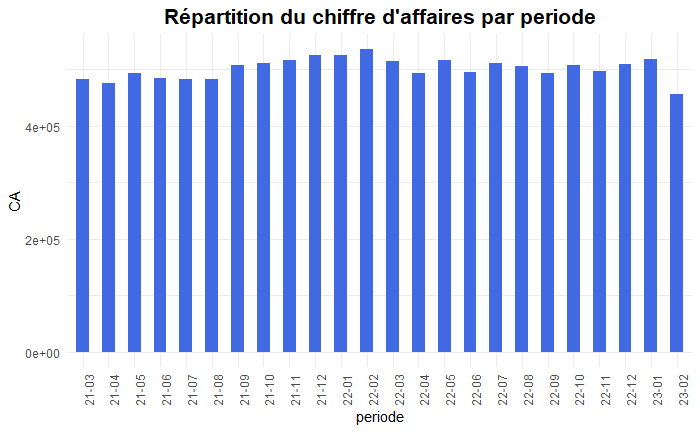

```r
CA_periode_corr %>%
  ggplot(aes(x = periode, y = CA)) +
  geom_col(width = 0.5, fill = "royalblue") +
  labs(title = "Répartition du chiffre d'affaires par periode") +
  theme_minimal() +
  theme(plot.title = element_text(size = 16L,
                                  face = "bold",
                                  hjust = 0.5)) +
  theme(axis.text.x = element_text(angle = 90))
```

**Décomposition saisonnière par moyennes mobiles**

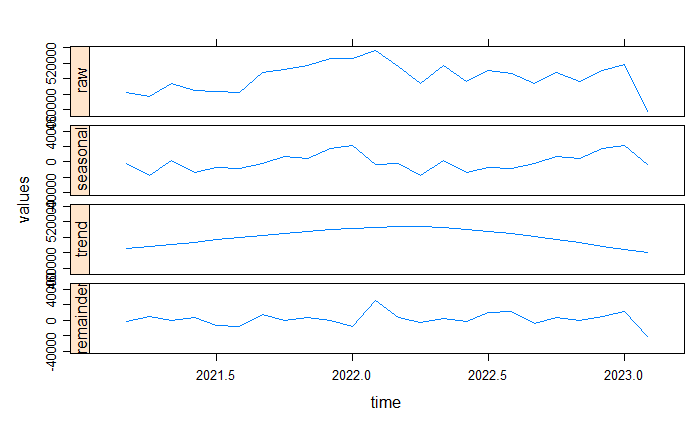

```r
library(stlplus)    # Seasonal Decomposition of Time Series by Loess
decomp_CA_stl <- stlplus(CA.ts, s.window = "periodic")
plot(decomp_CA_stl)
```

Une tendance montante au 1er trimestre 2022, en chute au-delà.

```r
stl <- decomp_CA_stl$data
round(sum(stl$seasonal), 2) # valeur nulle car schéma additif
```

```
[1] 0
```

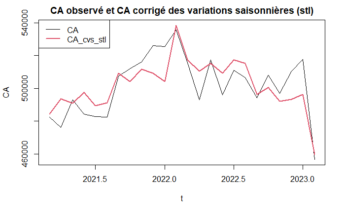

```r
CA_cvs_stl <-
  CA.ts - stl$seasonal  # schéma additif retenu par la méthode

ts.plot(
  CA.ts,
  CA_cvs_stl,
  xlab = "t",
  ylab = "CA",
  col = c(1, 2),
  lwd = c(1, 2),
  main = "CA observé et CA corrigé des variations saisonnières (stl)"
)
legend(
  "topleft",
  legend = c("CA", "CA_cvs_stl"),
  col = c(1, 2),
  lwd = c(1, 2)
)
```

### Analyse de la clientèle

Détermination de l’âge / positionnement en 2023

```r
customers$age  <-  2023 - customers$birth
```

```r
head(customers)
```

| client_id | sex | birth | age |
| --- | --- | --- | --- |
| c_4410 | f | 1967 | 56 |
| c_7839 | f | 1975 | 48 |
| c_1699 | f | 1984 | 39 |
| c_5961 | f | 1962 | 61 |
| c_5320 | m | 1943 | 80 |
| c_415 | m | 1993 | 30 |

```r
customers %>%
  group_by(sex) %>%
  summarise(
    age_max = max(age),
    age_min = min(age),
    age_mean = mean(age),
    age_median = median(age),
    age_sd = sd(age),
    count = n()
  )
```

| sex | age_max | age_min | age_mean | age_median | age_sd | count |
| --- | --- | --- | --- | --- | --- | --- |
| f | 94 | 19 | 45.00512 | 44 | 17.09824 | 4491 |
| m | 94 | 19 | 44.40828 | 43 | 16.71966 | 4132 |

Hommes et femmes sont très proches sur toutes les valeurs d’âges et même en nombre.

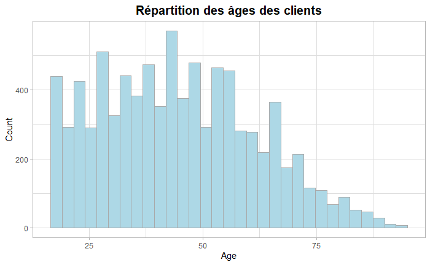

```r
ggplot(customers) +
  aes(x = age) +
  geom_histogram(
    binwidth = function(x)
      2 * IQR(x) / (length(x) ^ (1 / 3)),
    fill = "lightblue",
    color = "darkgrey"
  ) +
  labs(x = "Age",
       y = "Count",
       title = "Répartition des âges des clients") +
  theme_light() +
  theme(plot.title = element_text(size = 15L,
                                  face = "bold",
                                  hjust = 0.5))
```

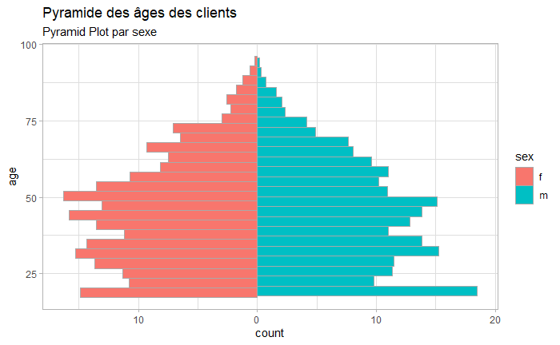

```r
ggplot(customers, aes(fill = sex)) +
  geom_histogram(
    data = subset(customers, sex == "f"),
    linewidth = 0.1,
    binwidth = function(x)
      2 * IQR(x) / (length(x) ^ (1 / 3)),
    aes(x = age, y = after_stat(count) * (-1)),
    color = "darkgrey"
  ) +
  geom_histogram(
    data = subset(customers, sex == "m"),
    linewidth = 0.1,
    binwidth = function(x)
      2 * IQR(x) / (length(x) ^ (1 / 3)),
    aes(x = age),
    color = "darkgrey"
  ) +
  scale_y_continuous(labels = paste0(as.character(c(
    seq(20, 0, -10), seq(10, 20, 10)
  )))) +
  ylab("count") +  coord_flip() +
  labs(title = "Pyramide des âges des clients", subtitle = "Pyramid Plot par sexe") + theme_light()
```

#### Fusion des données transactions et clients

```r
custom_prod  <-  trans_prod %>%
  tidylog::left_join(customers, by = "client_id")
```

```
left_join: added 3 columns (sex, birth, age)
           > rows only in x         0
           > rows only in y  (     23)
           > matched rows     679,332
           >                 =========
           > rows total       679,332
```

```r
head(custom_prod)
```

| id_prod | date | session_id | client_id | price | categ | periode | date_courte | sex | birth | age |
| --- | --- | --- | --- | --- | --- | --- | --- | --- | --- | --- |
| 0_1518 | 2022-05-20 13:21:29 | s_211425 | c_103 | 4.18 | 0 | 22-05 | 2022-05-20 | f | 1986 | 37 |
| 1_251 | 2022-02-02 07:55:19 | s_158752 | c_8534 | 15.99 | 1 | 22-02 | 2022-02-02 | m | 1988 | 35 |
| 0_1277 | 2022-06-18 15:44:33 | s_225667 | c_6714 | 7.99 | 0 | 22-06 | 2022-06-18 | f | 1968 | 55 |
| 2_209 | 2021-06-24 04:19:29 | s_52962 | c_6941 | 69.99 | 2 | 21-06 | 2021-06-24 | m | 2000 | 23 |
| 0_1509 | 2023-01-11 08:22:08 | s_325227 | c_4232 | 4.99 | 0 | 23-01 | 2023-01-11 | m | 1980 | 43 |
| 0_1418 | 2022-10-20 15:59:16 | s_285425 | c_1478 | 8.57 | 0 | 22-10 | 2022-10-20 | f | 1972 | 51 |

```r
summary(custom_prod)
```

```
   id_prod               date                         session_id         client_id             price        categ
 Length:679332      Min.   :2021-03-01 00:01:07.83   Length:679332      Length:679332      Min.   :  0.62   0:415680
 Class :character   1st Qu.:2021-09-08 09:14:25.05   Class :character   Class :character   1st Qu.:  8.87   1:227169
 Mode  :character   Median :2022-03-03 07:50:20.81   Mode  :character   Mode  :character   Median : 13.99   2: 36483
                    Mean   :2022-03-03 15:13:19.30                                         Mean   : 17.45
                    3rd Qu.:2022-08-30 23:57:08.55                                         3rd Qu.: 18.99
                    Max.   :2023-02-28 23:58:30.78                                         Max.   :300.00
   periode           date_courte             sex                birth           age
 Length:679332      Min.   :2021-03-01   Length:679332      Min.   :1929   Min.   :19.00
 Class :character   1st Qu.:2021-09-08   Class :character   1st Qu.:1970   1st Qu.:36.00
 Mode  :character   Median :2022-03-03   Mode  :character   Median :1980   Median :43.00
                    Mean   :2022-03-03                      Mean   :1978   Mean   :45.19
                    3rd Qu.:2022-08-30                      3rd Qu.:1987   3rd Qu.:53.00
                    Max.   :2023-02-28                      Max.   :2004   Max.   :94.00
```

Aucune valeur manquante.

**Chiffre d’affaires par clients**

```r
CA_clients <- custom_prod %>%
  group_by(client_id) %>%
  summarise(CA = sum(price),
            prop = round(sum(price) / CA_total * 100, 2)) %>%
  arrange(desc(CA))
head(CA_clients, 10)
```

| client_id | CA | prop |
| --- | --- | --- |
| c_1609 | 324033.35 | 2.73 |
| c_4958 | 289760.34 | 2.44 |
| c_6714 | 153658.86 | 1.30 |
| c_3454 | 113667.90 | 0.96 |
| c_3263 | 5276.87 | 0.04 |
| c_1570 | 5271.62 | 0.04 |
| c_2899 | 5214.05 | 0.04 |
| c_2140 | 5208.82 | 0.04 |
| c_7319 | 5155.77 | 0.04 |
| c_8026 | 5092.57 | 0.04 |

```r
# les 10 premiers clients par CA
```

*4 gros clients (libraires) se détachent nettement et constituent, de fait, des outliers (CA > 100 k€ contre 5.3 k€ pour le 5e).*

#### Mesure de l’inégalité de la répartition du chiffre d’affaires par client / Courbe de Lorenz

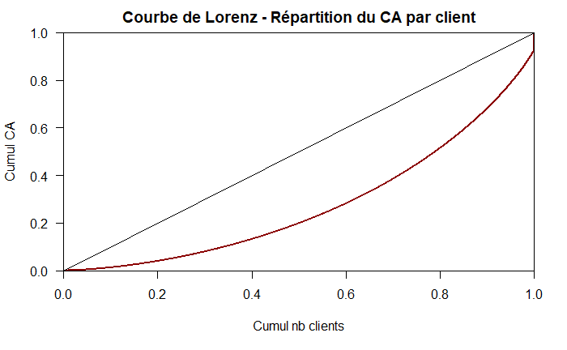

```r
plot(Lc(CA_clients$CA), col = "darkred", lwd = 2, main="Courbe de Lorenz - Répartition du CA par client", xlab = "Cumul nb clients", ylab= "Cumul CA")
```

On compare les valeurs cumulées des déciles avec la droite d’équi-répartition, c’est une estimation de l’inégalité, ici moyennement marquée. Toutefois, une anomalie est repérée en fin de courbe.

**Indice ou coefficient de Gini**

```r
ineq(CA_clients$CA, type = "Gini") # G = 2 fois l'aire comprise entre la droite et la courbe / plus G est fort, plus l'inégalité est forte.
```

```
[1] 0.4463949
```

Le coefficient de Gini est proche de 0.5, l’inégalité est moyennement marquée.

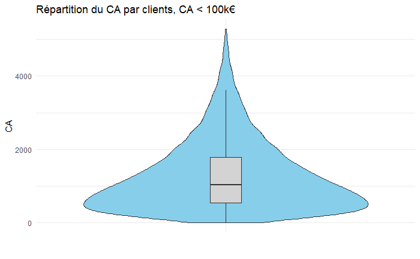

```r
CA_clients %>%
  filter(CA_clients$CA < 100000) %>%
  ggplot(aes(x = "", y = CA))   +
  geom_violin(fill = "skyblue") +
  geom_boxplot(
    width = 0.1,
    outlier.shape = NA,
    show.legend = FALSE,
    fill = "lightgrey"
  ) +
  labs(title = "Répartition du CA par clients, CA < 100k€") +
  xlab("") +
  theme_minimal()
```

#### Etude des relations entre clientèle et produits

**Existe-t-il une relation significative entre le genre de la clientèle et la catégorie de livres achetés ?**

*Tableau de contingence*

```r
sex_categ <- table(custom_prod$sex, custom_prod$categ)
sex_categ
```

```
         0      1      2
  f 206220 114899  17283
  m 209460 112270  19200
```

*Pearson’s Chi-squared Test*

```r
chisq.test(sex_categ)
```

```
    Pearson's Chi-squared test

data:  sex_categ
X-squared = 147, df = 2, p-value < 2.2e-16
```

Ici, la p-value est très proche de 0, en-dessous du seuil de décision choisi préalablement au test (5% retenu par défaut par le test du Chi2). On peut donc rejeter l’hypothèse d’indépendance des lignes et des colonnes du tableau. Sex et categ sont des variables corrélées.

```r
chisq.residuals(sex_categ) # la fonction est attachée au package {questionr}
```

```
        0     1     2
  f -1.86  5.16 -6.61
  m  1.85 -5.14  6.58
```

L’interprétation des résidus standardisés est la suivante :

- si la valeur du résidu pour une case est inférieure à -2, alors il y a une sous-représentation de cette case dans le tableau : les effectifs sont significativement plus faibles que ceux attendus sous l’hypothèse d’indépendance
- à l’inverse, si le résidu est supérieur à 2, il y a sur-représentation de cette case
- si le résidu est compris entre -2 et 2, il n’y a pas d’écart à l’indépendance significatif

Les indicateurs recueillis permettent de préciser : - que les femmes sont davantage attirées par les ouvrages de catégorie 1 que les hommes - que les hommes sont davantage attirés par les ouvrages de catégorie 2 que les femmes

C’est ce que permet de visualiser :

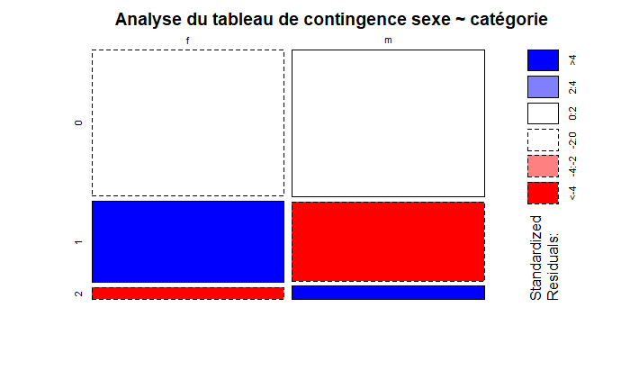

```r
mosaicplot(sex_categ, shade = TRUE, main = "Analyse du tableau de contingence sexe ~ catégorie")
```

#### En quoi l’âge des clients est-il corrélé aux variables : montant total des achats, fréquence d’achat, taille du panier moyen, catégories des livres achetés ?

**Détermination des variables à considérer dans l’analyse**

```r
cumul_clients <- custom_prod %>%
  group_by(client_id) %>%
  summarise(
    CA = sum(price, na.rm = TRUE),
    freq = n_distinct(session_id),
    avg_basket = n() / freq,
    age = max(age)     # permet de conserver l'âge par-delà l'aggrégation
  )

head(cumul_clients)
```

| client_id | CA | freq | avg_basket | age |
| --- | --- | --- | --- | --- |
| c_1 | 558.18 | 33 | 1.181818 | 68 |
| c_10 | 1353.60 | 34 | 1.705882 | 67 |
| c_100 | 254.85 | 5 | 1.600000 | 31 |
| c_1000 | 2261.89 | 93 | 1.344086 | 57 |
| c_1001 | 1812.86 | 47 | 2.170213 | 41 |
| c_1002 | 415.78 | 19 | 1.894737 | 41 |

Les 4 clients outliers relevés ont une incidence très forte et sont à écarter avant l’analyse des relations entre les variables étudiées.

**Matrice de corrélation - méthode de Pearson**

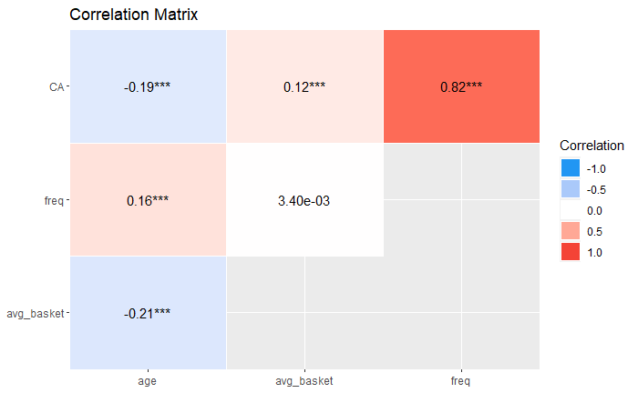

```r
# Suppression des outliers repérés
cumul_clients_wo_outliers <- cumul_clients %>%
   filter(CA < 100000)

library(correlation)
plot(summary(correlation(cumul_clients_wo_outliers)))
```

Les coefficients de corrélation en lien avec l’âge sont tous significatifs, certains corrélés négativement à l’âge, d’autres positivement.

Les régressions linéaires sont-elles un bon modèle de prédiction ?

#### Régressions linéaires portant sur les variables numériques

##### Sur l’âge et les données calculées

###### Age et chiffre d’affaires

```r
reg_lin_age_CA <- lm(formula = CA ~ age, data = cumul_clients_wo_outliers)
summary(reg_lin_age_CA)
```

```
Call:
lm(formula = CA ~ age, data = cumul_clients_wo_outliers)

Residuals:
    Min      1Q  Median      3Q     Max
-1539.1  -700.9  -235.9   500.1  3987.0

Coefficients:
             Estimate Std. Error t value Pr(>|t|)
(Intercept) 1752.2781    28.5974   61.27   <2e-16 ***
age          -10.6291     0.5979  -17.78   <2e-16 ***
---
Signif. codes:  0 ‘***’ 0.001 ‘**’ 0.01 ‘*’ 0.05 ‘.’ 0.1 ‘ ’ 1

Residual standard error: 937.4 on 8594 degrees of freedom
Multiple R-squared:  0.03547,   Adjusted R-squared:  0.03536
F-statistic:   316 on 1 and 8594 DF,  p-value: < 2.2e-16
```

Au risque de 5%, l’hypothèse nulle est rejetée. Les variables sont corrélées, mais le coefficient de détermination R2 est très faible, le modèle linéaire représente imparfaitement le rapport entre les variables.

Ce que confirme la visualisation.

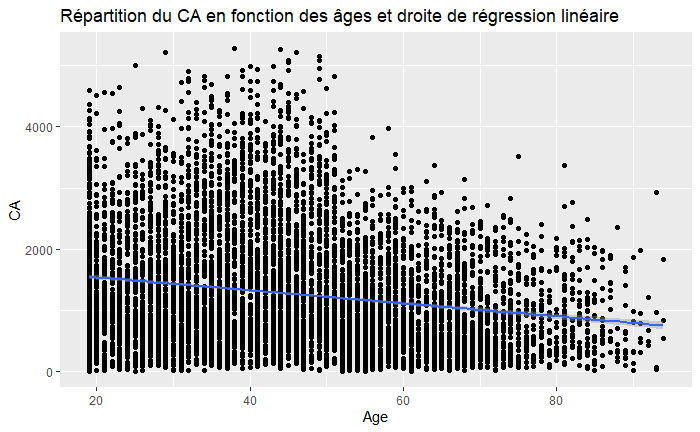

```r
ggplot(cumul_clients_wo_outliers, aes(x = age, y = CA)) +
  geom_point() +
  stat_smooth(method = "lm") +
  xlab("Age") +
  ylab("CA")+
  ggtitle("Répartition du CA en fonction des âges et droite de régression linéaire")
```

La pente est négative. Plus le client est âgé, moins il achète.

**Vérification de la normalité des résidus**

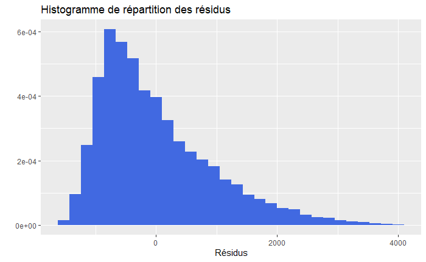

```r
ggplot(cumul_clients_wo_outliers, aes(x = reg_lin_age_CA$residuals)) +
  geom_histogram(aes(y = after_stat(density)), fill = "royalblue") +
  ggtitle("Histogramme de répartition des résidus") +
  xlab("Résidus") +
  ylab("")
```

**Test de Kolmogorov-Smirnov**

```r
ks.test(reg_lin_age_CA$residuals, "pnorm")
```

```
    Asymptotic one-sample Kolmogorov-Smirnov test

data:  reg_lin_age_CA$residuals
D = 0.59523, p-value < 2.2e-16
alternative hypothesis: two-sided
```

Le test de normalité rejette l’hypothèse nulle : la distribution des résidus ne suit pas une loi normale.

Vérification de l’hétéroscédasticité (répartition inégale des résidus)

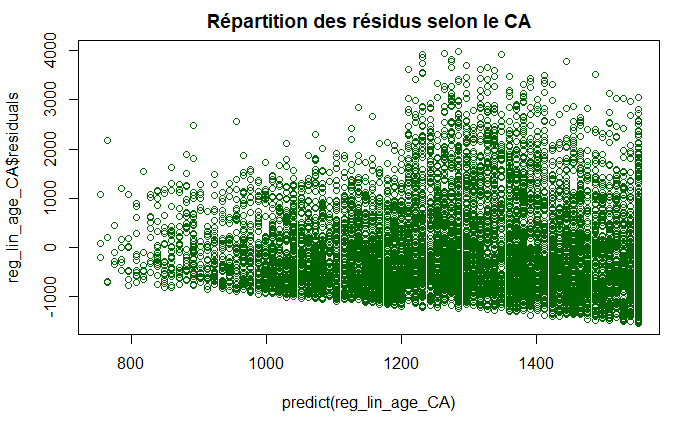

```r
plot(predict(reg_lin_age_CA), reg_lin_age_CA$residuals, col="darkgreen", main="Répartition des résidus selon le CA")
```

La répartition des résidus est inégale, ce que confirme le **Test de Breusch-Pagan**

```r
library(lmtest)

bptest(reg_lin_age_CA)
```

```
    studentized Breusch-Pagan test

data:  reg_lin_age_CA
BP = 142.62, df = 1, p-value < 2.2e-16
```

Au risque de 5% nous rejetons l’hypothèse nulle : il y a hétéroscédasticité. Pas de normalité des distributions, hétéroscedasticité des résidus, le modèle linéaire n’est pas robuste.

###### Age et moyenne du panier

```r
reg_lin_age_basket <- lm(formula =avg_basket ~ age, data = cumul_clients_wo_outliers)
summary(reg_lin_age_basket)
```

```
Call:
lm(formula = avg_basket ~ age, data = cumul_clients_wo_outliers)

Residuals:
    Min      1Q  Median      3Q     Max
-1.1953 -0.5116 -0.0388  0.4184  6.1387

Coefficients:
              Estimate Std. Error t value Pr(>|t|)
(Intercept)  2.3544662  0.0198348   118.7   <2e-16 ***
age         -0.0083750  0.0004147   -20.2   <2e-16 ***
---
Signif. codes:  0 ‘***’ 0.001 ‘**’ 0.01 ‘*’ 0.05 ‘.’ 0.1 ‘ ’ 1

Residual standard error: 0.6502 on 8594 degrees of freedom
Multiple R-squared:  0.04531,   Adjusted R-squared:  0.0452
F-statistic: 407.8 on 1 and 8594 DF,  p-value: < 2.2e-16
```

La p-value est proche de zéro, le R2 ajusté est faible, si les variables sont bien corrélées, la linéarité n’est pas le bon modèle. Ce que confirme la visualisation.

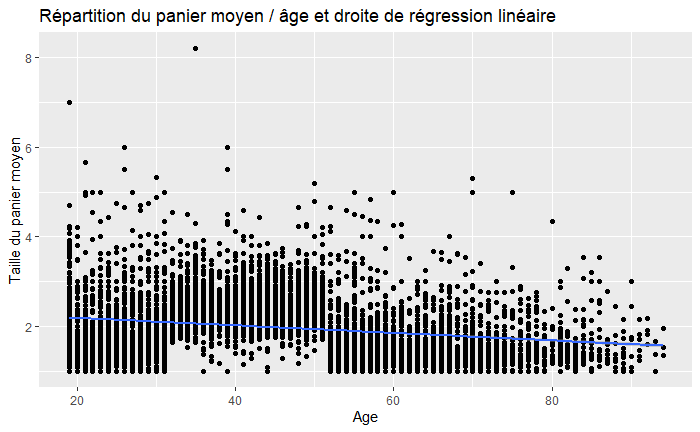

```r
ggplot(cumul_clients_wo_outliers, aes(x = age, y = avg_basket)) +
  geom_point() +
  stat_smooth(method = "lm") +
  xlab("Age") +
  ylab("Taille du panier moyen") +
  ggtitle("Répartition du panier moyen / âge et droite de régression linéaire")
```

Tests de normalité de la distribution et d’hétéroscédasticité des résidus :

```r
print(ks.test(reg_lin_age_basket$residuals, "pnorm"))
```

```
    Asymptotic one-sample Kolmogorov-Smirnov test

data:  reg_lin_age_basket$residuals
D = 0.14137, p-value < 2.2e-16
alternative hypothesis: two-sided
```

```r
print(bptest(reg_lin_age_basket))
```

```
    studentized Breusch-Pagan test

data:  reg_lin_age_basket
BP = 70.043, df = 1, p-value < 2.2e-16
```

Tout comme pour le CA, le modèle linéaire liant panier moyen à l’âge est mal assuré.

###### Age et fréquence d’achat

```r
reg_lin_age_freq <- lm(formula = freq ~ age, data = cumul_clients_wo_outliers)
summary(reg_lin_age_freq)
```

```
Call:
lm(formula = freq ~ age, data = cumul_clients_wo_outliers)

Residuals:
   Min     1Q Median     3Q    Max
-48.75 -21.41  -9.72  12.55 129.79

Coefficients:
            Estimate Std. Error t value Pr(>|t|)
(Intercept) 23.68989    0.92956   25.48   <2e-16 ***
age          0.30068    0.01944   15.47   <2e-16 ***
---
Signif. codes:  0 ‘***’ 0.001 ‘**’ 0.01 ‘*’ 0.05 ‘.’ 0.1 ‘ ’ 1

Residual standard error: 30.47 on 8594 degrees of freedom
Multiple R-squared:  0.0271,    Adjusted R-squared:  0.02698
F-statistic: 239.3 on 1 and 8594 DF,  p-value: < 2.2e-16
```

La p-value permet de rejeter la nullité des coefficients. Le R2 est très faible. La linéarité explique peu la relation.

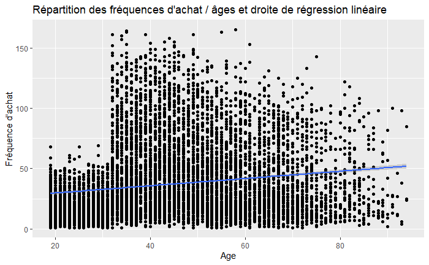

```r
ggplot(cumul_clients_wo_outliers, aes(x = age, y = freq)) +
  geom_point() +
  stat_smooth(method = "lm") +
  xlab("Age") +
  ylab("Fréquence d'achat") +
  ggtitle("Répartition des fréquences d'achat / âges et droite de régression linéaire")
```

Tests de normalité de la distribution et d’hétéroscédasticité des résidus :

```r
print(ks.test(reg_lin_age_freq$residuals, "pnorm"))
```

```
    Asymptotic one-sample Kolmogorov-Smirnov test

data:  reg_lin_age_freq$residuals
D = 0.59697, p-value < 2.2e-16
alternative hypothesis: two-sided
```

```r
print(bptest(reg_lin_age_freq))
```

```
    studentized Breusch-Pagan test

data:  reg_lin_age_freq
BP = 61.355, df = 1, p-value = 4.765e-15
```

#### Relations entre les âges et les catégories

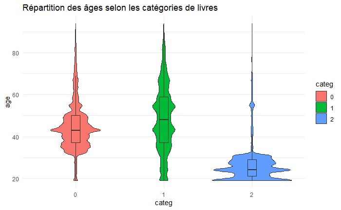

```r
ggplot(custom_prod) +
  aes(x = categ, y = age, fill = categ) +
  geom_violin(adjust = 1L,
              scale = "area") +
  geom_boxplot(width = 0.1,
               outlier.shape = NA,
               show.legend = FALSE) +
  theme_minimal() +
  ggtitle("Répartition des âges selon les catégories de livres")
```

Il existe une tendance forte des plus jeunes sur la catégorie 2. On constate beaucoup de valeurs extrêmes et d’amplitude pour chacune des catégories. Les conditions sont-elles réunies pour réaliser une analyse des variances ?

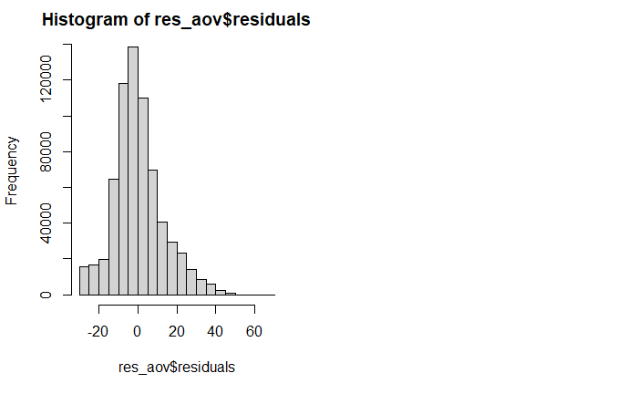

```r
res_aov <- aov(age ~ categ,
               data = custom_prod)

par(mfrow = c(1, 2)) # combine plots

# histogram
hist(res_aov$residuals)
```

```r
# QQ-plot
qqPlot(res_aov$residuals,
  id = FALSE # id = FALSE to remove point identification
)
```

[output not shown]

Test de normalité de distribution des échantillons (Kolmogorov-Smirnov Test)

```r
print(ks.test(custom_prod[custom_prod$categ=="0",]$age, "pnorm"))
```

```
    Asymptotic one-sample Kolmogorov-Smirnov test

data:  custom_prod[custom_prod$categ == "0", ]$age
D = 1, p-value < 2.2e-16
alternative hypothesis: two-sided
```

```r
print(ks.test(custom_prod[custom_prod$categ=="1",]$age, "pnorm"))
```

```
    Asymptotic one-sample Kolmogorov-Smirnov test

data:  custom_prod[custom_prod$categ == "1", ]$age
D = 1, p-value < 2.2e-16
alternative hypothesis: two-sided
```

```r
print(ks.test(custom_prod[custom_prod$categ=="2",]$age, "pnorm"))
```

```
    Asymptotic one-sample Kolmogorov-Smirnov test

data:  custom_prod[custom_prod$categ == "2", ]$age
D = 1, p-value < 2.2e-16
alternative hypothesis: two-sided
```

```r
# Levene's test
library(car)

leveneTest(age ~ categ,
               data = custom_prod
)
```

```
Levene's Test for Homogeneity of Variance (center = median)
          Df F value    Pr(>F)
group      2   26092 < 2.2e-16 ***
      679329
---
Signif. codes:  0 ‘***’ 0.001 ‘**’ 0.01 ‘*’ 0.05 ‘.’ 0.1 ‘ ’ 1
```

Les distributions ne suivent pas une loi normale, pas d’homogénéité des variances, les tests d’analyse paramétrique de la variance ne sont pas adaptés. Recours à un test non paramétrique : test de Kruskal-Wallis.

```r
kruskal.test(custom_prod$age, custom_prod$categ) # test non paramétrique
```

```
    Kruskal-Wallis rank sum test

data:  custom_prod$age and custom_prod$categ
Kruskal-Wallis chi-squared = 79351, df = 2, p-value < 2.2e-16
```

Au risque de 5%, nous pouvons rejeter l’hypothèse d’indépendance des variables, elle sont corrélées.

```r
custom_prod %>%
  group_by(categ) %>%
  summarise(
    age_max = max(age),
    age_min = min(age),
    age_mean = mean(age),
    age_median = median(age),
    age_sd = sd(age),
    count = n()
  )
```

| categ | age_max | age_min | age_mean | age_median | age_sd | count |
| --- | --- | --- | --- | --- | --- | --- |
| 0 | 94 | 19 | 44.89762 | 43 | 11.209482 | 415680 |
| 1 | 94 | 19 | 48.65124 | 48 | 15.495910 | 227169 |
| 2 | 94 | 19 | 26.94803 | 24 | 9.798143 | 36483 |

La catégorie 2 se détache nettement par son public sensiblement plus jeune. Les moyennes d’âges sont similaires entre les catégories 0 et 1. Les mêmes âges extrêmes sont présents sur les 3 catégories.

Approche visuelle affinée des différences d’achats de livres selon les âges :

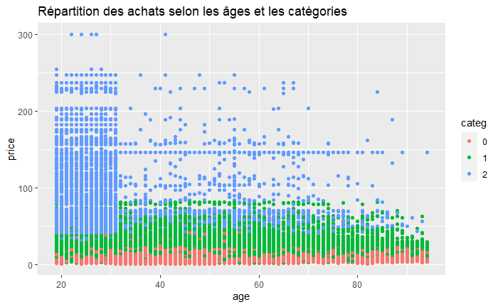

```r
ggplot(custom_prod) +
  geom_point(
    aes(x = age, y = price, color = categ)
  ) +
  ggtitle("Répartition des achats selon les âges et les catégories")
```